# Modeling and prediction for movies

## Setup

### Load packages

```r
library(ggplot2)
library(dplyr)
library(statsr)
library(corrplot)
library(gridExtra)
```

### Load data

```r
load("movies.Rdata")
```

## Part 1: Data

The data in this study comprises of movie features and ratings collected mainly from two websites the IMDB and Rotten Tomatoes. The data consists of 651 randomly sampled movies, hence, one can generalize the results to the population of interest. However, no causation can be established because random assignment was not used in this study.

## Part 2: Research question

For the subject project we try to investigate what factors determine or influence the popularity of a movie.

For this we will focus on the parameter imdb_rating, this will be our response variable.

The research question is important as it helps the studio invest on similar films and generate maximum revenue on such investments. A movie with good rating on IMDB is likely to be popular and provide other revenue streams like rentals and online streaming.

## Part 3: Exploratory data analysis

Data Cleaning: - Release days - given the long timespan involved (1970 to 2014), day of the month was removed to simplify the model. -IMDB and Rotten Tomatoes URLs will be removed as they have no significance for this analysis. -Similarly Studio variable is a factor variable with a large number of levels (2011).  
-Movie title, director, actors - These variables could be the subject of additional research: text-based analysis on titles, or considering a director/actor’s popularity at the time the movie was released as potential factors, to name a few. However, this deeper analysis is outside the scope of the course.

```r
movies_df <- movies %>%
  select(-c(title,studio,director,actor1:actor5,imdb_url,rt_url)) %>%
  select(-contains("_rel_day")) %>% na.omit()

summary(movies_df)
```

```
##         title_type                 genre        runtime        mpaa_rating
##  Documentary : 52   Drama             :303   Min.   : 39.00   G      : 18
##  Feature Film:585   Comedy            : 87   1st Qu.: 92.25   NC-17  :  2
##  TV Movie    :  5   Action & Adventure: 63   Median :103.00   PG     :115
##                     Mystery & Suspense: 59   Mean   :105.93   PG-13  :132
##                     Documentary       : 49   3rd Qu.:116.00   R      :327
##                     Horror            : 23   Max.   :267.00   Unrated: 48
##                     (Other)           : 58
##  thtr_rel_year  thtr_rel_month    dvd_rel_year  dvd_rel_month     imdb_rating
##  Min.   :1972   Min.   : 1.000   Min.   :1991   Min.   : 1.000   Min.   :1.9
##  1st Qu.:1991   1st Qu.: 4.000   1st Qu.:2001   1st Qu.: 3.000   1st Qu.:5.9
##  Median :2000   Median : 7.000   Median :2004   Median : 6.000   Median :6.6
##  Mean   :1998   Mean   : 6.737   Mean   :2004   Mean   : 6.341   Mean   :6.5
##  3rd Qu.:2007   3rd Qu.:10.000   3rd Qu.:2008   3rd Qu.: 9.000   3rd Qu.:7.3
##  Max.   :2014   Max.   :12.000   Max.   :2015   Max.   :12.000   Max.   :9.0
##
##  imdb_num_votes           critics_rating critics_score    audience_rating
##  Min.   :   180   Certified Fresh:135    Min.   :  1.00   Spilled:271
##  1st Qu.:  4830   Fresh          :206    1st Qu.: 33.00   Upright:371
##  Median : 15508   Rotten         :301    Median : 61.50
##  Mean   : 58296                          Mean   : 57.84
##  3rd Qu.: 59034                          3rd Qu.: 83.00
##  Max.   :893008                          Max.   :100.00
##
##  audience_score  best_pic_nom best_pic_win best_actor_win best_actress_win
##  Min.   :11.00   no :620      no :635      no :549        no :570
##  1st Qu.:46.00   yes: 22      yes:  7      yes: 93        yes: 72
##  Median :65.00
##  Mean   :62.44
##  3rd Qu.:80.00
##  Max.   :97.00
##
##  best_dir_win top200_box
##  no :599      no :627
##  yes: 43      yes: 15
##
##
##
##
##
```

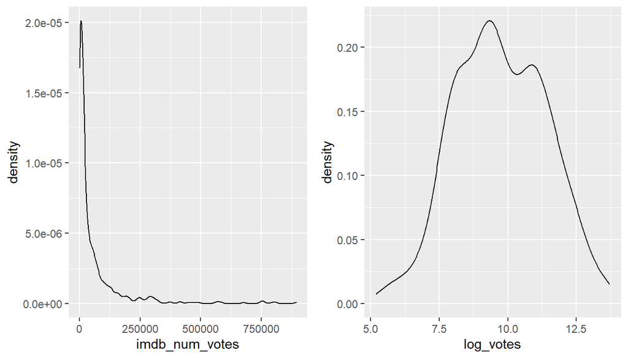

```r
movies_df <- mutate(movies_df, log_votes=log(imdb_num_votes))
x1 <- ggplot(movies_df, aes(x=imdb_num_votes)) + geom_density()
x2 <- ggplot(movies_df, aes(x=log_votes)) + geom_density()
grid.arrange(x1,x2, ncol=2)
```

```r
movies_df <- select(movies_df, -imdb_num_votes)
```

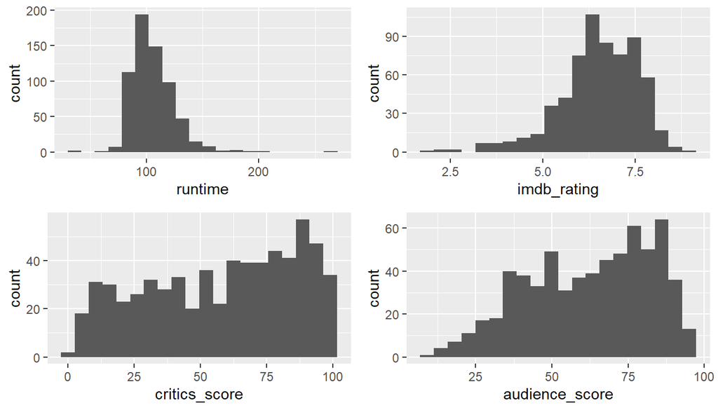

```r
runtime <- ggplot(movies_df, aes(x=runtime)) + geom_histogram(bins = 20)
imdb_rat <- ggplot(movies_df, aes(x=imdb_rating)) + geom_histogram(bins = 20)
critics_score <- ggplot(movies_df, aes(x=critics_score)) + geom_histogram(bins = 20)
audience_score <- ggplot(movies_df, aes(x=audience_score)) + geom_histogram(bins = 20)
grid.arrange(runtime, imdb_rat,critics_score, audience_score, ncol=2)
```

We notice that there is stronger skewness in the IMDB and Audience scores, which is reasonable given that these are ratings provided by the population.

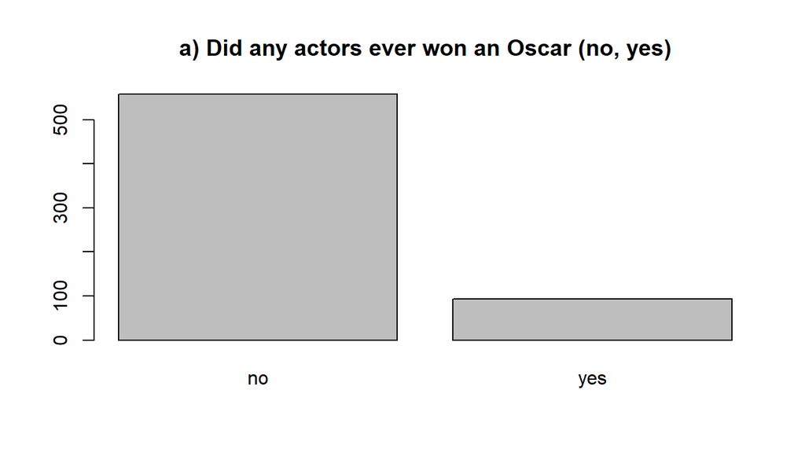

```r
barplot(summary(movies$best_actor_win),main="a) Did any actors ever won an Oscar (no, yes)")
```

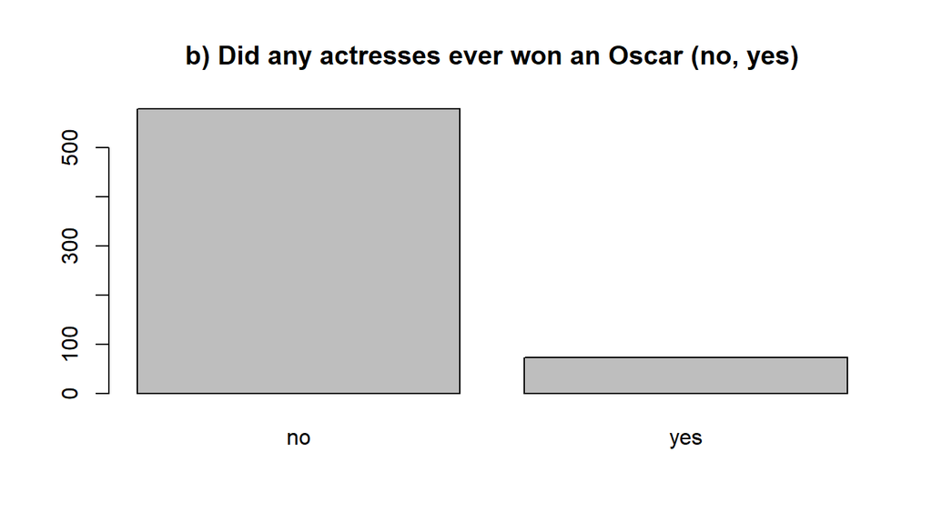

```r
barplot(summary(movies$best_actress_win),main="b) Did any actresses ever won an Oscar (no, yes)")
```

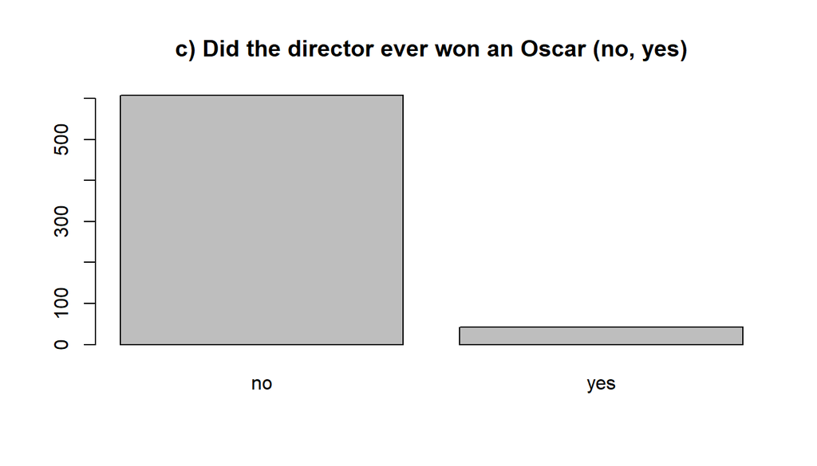

```r
barplot(summary(movies$best_dir_win),main="c) Did the director ever won an Oscar (no, yes)")
```

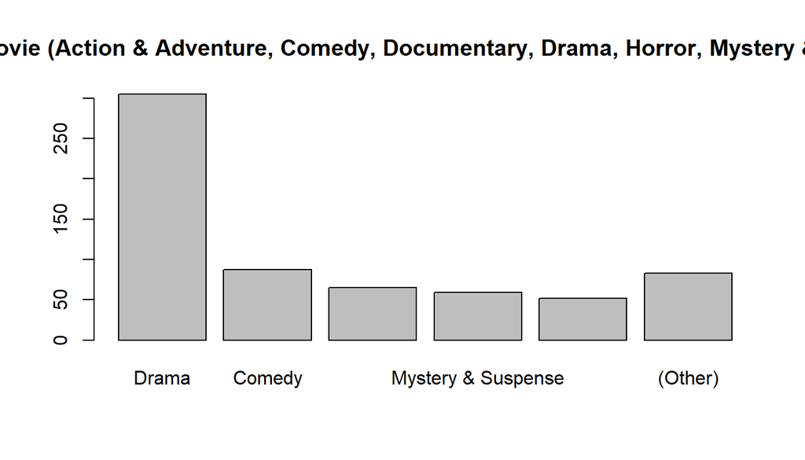

```r
barplot(summary(movies$genre,maxsum=6),main="d) Genre of movie (Action & Adventure, Comedy, Documentary, Drama, Horror, Mystery & Suspense, Other")
```

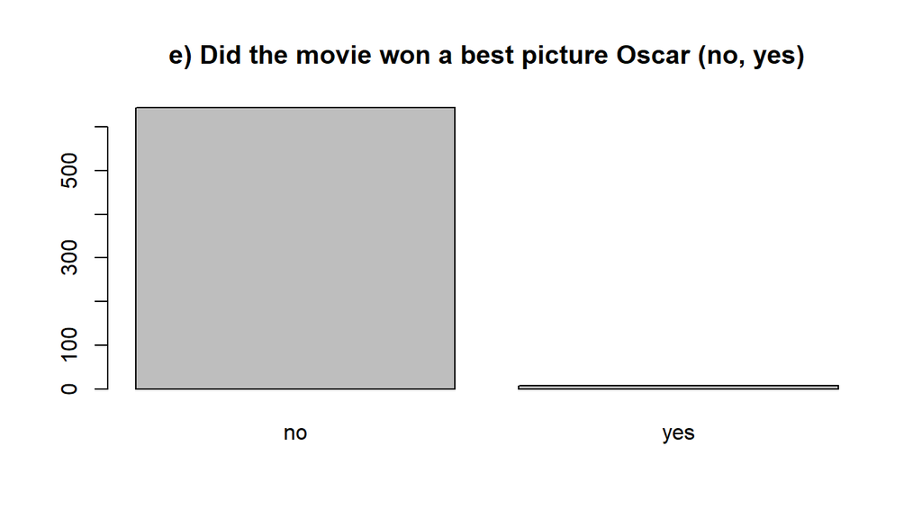

```r
barplot(summary(movies$best_pic_win),main="e) Did the movie won a best picture Oscar (no, yes)")
```

For the categorical values barplots were used. From the figures we can seee that The distribution of average runtime of a movie is slightly right skewed.The critics scores are nearly uniformly distributed, but slightly left skewed. The score given by the audience is nearly uniform left skewed distribution. In the barplots we note that there are few Oscar winners in the entire sample, which may not give a represesntative effect of ths variable. We now want to check out the correlation between these variables.

```r
#audience score vs critics rating
gr1 <- ggplot(movies_df, aes(x=audience_score, y=critics_rating))+geom_boxplot()+ ggtitle("Audience score vs. Critics rating")
```

Let us further investigate the correlation among the various variables and how they affect each other.

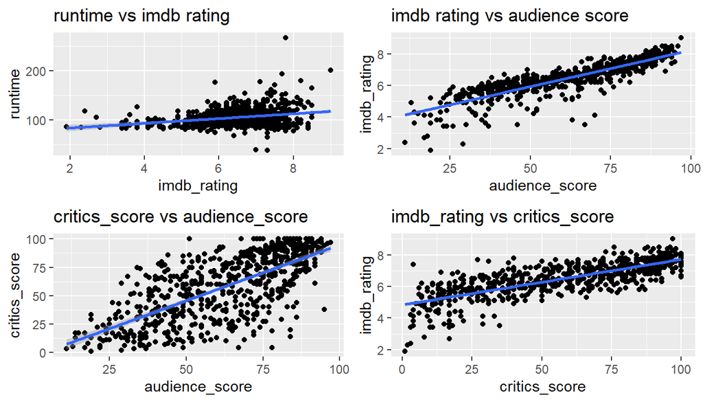

```r
plt1 <- ggplot(movies_df,aes(x=imdb_rating, y= runtime))+geom_point() + stat_smooth(method = "lm", evel=0.95)+ggtitle("runtime vs imdb rating")
plt2 <- ggplot(movies_df,aes(x=audience_score, y=imdb_rating))+geom_point() + stat_smooth(method = "lm", level=0.95)+ggtitle("imdb rating vs audience score")
plt3 <- ggplot(movies_df, aes(x=audience_score,y=critics_score))+geom_point()+stat_smooth(method="lm", level=0.95)+ggtitle("critics_score vs audience_score")
plt4 <-ggplot(movies_df, aes(x= critics_score, y=imdb_rating))+geom_point()+stat_smooth(method="lm", level=0.95) + ggtitle("imdb_rating vs critics_score")

grid.arrange(plt1, plt2,plt3, plt4, ncol=2)
```

Let us create the correlation matrix

```r
isNumeric <- sapply(tbl_df(movies_df), is.numeric)
```

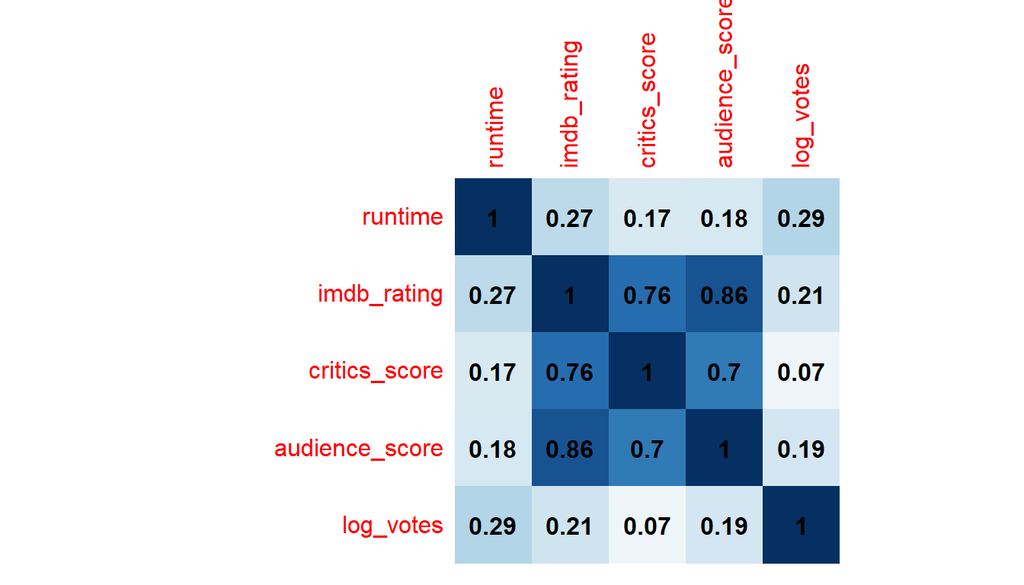

```r
cm_mov <- select(movies_df,which(isNumeric)) %>% select(-contains("_rel_")) %>% cor(use = "complete.obs")
corrplot(cm_mov, method="shade", cl.pos = "n", addCoef.col = "black")
```

The correlation matrix shown above indicates that our response variable - imdb_rating - has strong positive correlation with the other scores, and less so with other selected numeric variables

## Part 4: Modeling

We will using a multiple regression to fit a model that will predict movie popularity. It starts with the full model as defined above, and will use a backward stepwise regression to arrive at a parsimonious model. Before performing the stepwise analysis, several variables were manually removed from the dataset. Variables like Number of votes(replaced with log votes), IMDB and Rotten Tomatoes URLs, Studio, Movie title, director, actors, Release day, Audience rating where removed to simplify the process as they are either insignificant to the analysis or contain irrelevant information. Additionally audience rating and critics rating variables are removed as these are categorical variables.

```r
movies_new = select(movies_df, -audience_rating, -critics_rating)
names(movies_new)
```

```
##  [1] "title_type"       "genre"            "runtime"          "mpaa_rating"
##  [5] "thtr_rel_year"    "thtr_rel_month"   "dvd_rel_year"     "dvd_rel_month"
##  [9] "imdb_rating"      "critics_score"    "audience_score"   "best_pic_nom"
## [13] "best_pic_win"     "best_actor_win"   "best_actress_win" "best_dir_win"
## [17] "top200_box"       "log_votes"
```

All other variables have been considered as shown above.

```r
fit1 <-lm(imdb_rating ~ ., data=movies_new)
summary(fit1)
```

```
##
## Call:
## lm(formula = imdb_rating ~ ., data = movies_new)
##
## Residuals:
##      Min       1Q   Median       3Q      Max
## -2.45034 -0.19051  0.03342  0.26107  1.17239
##
## Coefficients:
##                                  Estimate Std. Error t value Pr(>|t|)
## (Intercept)                     0.7551133  8.7664290   0.086  0.93139
## title_typeFeature Film         -0.2205556  0.1754140  -1.257  0.20911
## title_typeTV Movie             -0.3991202  0.2711576  -1.472  0.14156
## genreAnimation                 -0.4461635  0.1833170  -2.434  0.01523 *
## genreArt House & International  0.3869611  0.1482036   2.611  0.00925 **
## genreComedy                    -0.1096213  0.0790611  -1.387  0.16609
## genreDocumentary                0.3243023  0.1861557   1.742  0.08199 .
## genreDrama                      0.1316119  0.0715426   1.840  0.06631 .
## genreHorror                     0.0996862  0.1166678   0.854  0.39319
## genreMusical & Performing Arts  0.1277362  0.1608798   0.794  0.42751
## genreMystery & Suspense         0.2681551  0.0879535   3.049  0.00240 **
## genreOther                      0.0480926  0.1330945   0.361  0.71797
## genreScience Fiction & Fantasy -0.0555296  0.1735969  -0.320  0.74917
## runtime                         0.0037718  0.0011607   3.249  0.00122 **
## mpaa_ratingNC-17               -0.1511283  0.3518442  -0.430  0.66769
## mpaa_ratingPG                  -0.1616075  0.1313478  -1.230  0.21903
## mpaa_ratingPG-13               -0.1618908  0.1376305  -1.176  0.23995
## mpaa_ratingR                   -0.1075119  0.1321733  -0.813  0.41630
## mpaa_ratingUnrated             -0.1472025  0.1549928  -0.950  0.34262
## thtr_rel_year                  -0.0015684  0.0026609  -0.589  0.55580
## thtr_rel_month                  0.0075232  0.0054612   1.378  0.16884
## dvd_rel_year                    0.0026811  0.0055101   0.487  0.62673
## dvd_rel_month                   0.0064686  0.0055909   1.157  0.24773
## critics_score                   0.0101248  0.0009695  10.443  < 2e-16 ***
## audience_score                  0.0315879  0.0014316  22.064  < 2e-16 ***
## best_pic_nomyes                -0.0797170  0.1215902  -0.656  0.51232
## best_pic_winyes                 0.0389394  0.2111945   0.184  0.85378
## best_actor_winyes               0.0273443  0.0553942   0.494  0.62174
## best_actress_winyes             0.0605553  0.0608990   0.994  0.32044
## best_dir_winyes                 0.0322851  0.0800605   0.403  0.68690
## top200_boxyes                  -0.1207617  0.1273326  -0.948  0.34330
## log_votes                       0.0693749  0.0164570   4.216 2.87e-05 ***
## ---
## Signif. codes:  0 '***' 0.001 '**' 0.01 '*' 0.05 '.' 0.1 ' ' 1
##
## Residual standard error: 0.4592 on 610 degrees of freedom
## Multiple R-squared:  0.8262, Adjusted R-squared:  0.8173
## F-statistic: 93.52 on 31 and 610 DF,  p-value: < 2.2e-16
```

```r
fit2<- step(fit1, direction = "backward", trace = FALSE)
summary(fit2)
```

```
##
## Call:
## lm(formula = imdb_rating ~ genre + runtime + critics_score +
##     audience_score + log_votes, data = movies_new)
##
## Residuals:
##      Min       1Q   Median       3Q      Max
## -2.46021 -0.19703  0.03446  0.24879  1.15958
##
## Coefficients:
##                                  Estimate Std. Error t value Pr(>|t|)
## (Intercept)                     2.7271185  0.1569224  17.379  < 2e-16 ***
## genreAnimation                 -0.3615085  0.1640659  -2.203  0.02793 *
## genreArt House & International  0.3922433  0.1431358   2.740  0.00631 **
## genreComedy                    -0.1066173  0.0764786  -1.394  0.16379
## genreDocumentary                0.5021761  0.1069298   4.696 3.26e-06 ***
## genreDrama                      0.1310362  0.0672531   1.948  0.05181 .
## genreHorror                     0.1229962  0.1127545   1.091  0.27577
## genreMusical & Performing Arts  0.1848612  0.1509391   1.225  0.22113
## genreMystery & Suspense         0.2857168  0.0838715   3.407  0.00070 ***
## genreOther                      0.0132830  0.1300664   0.102  0.91869
## genreScience Fiction & Fantasy -0.0440350  0.1719564  -0.256  0.79797
## runtime                         0.0041422  0.0010334   4.008 6.85e-05 ***
## critics_score                   0.0104586  0.0009221  11.343  < 2e-16 ***
## audience_score                  0.0316231  0.0013701  23.081  < 2e-16 ***
## log_votes                       0.0649206  0.0134894   4.813 1.87e-06 ***
## ---
## Signif. codes:  0 '***' 0.001 '**' 0.01 '*' 0.05 '.' 0.1 ' ' 1
##
## Residual standard error: 0.4568 on 627 degrees of freedom
## Multiple R-squared:  0.8232, Adjusted R-squared:  0.8193
## F-statistic: 208.5 on 14 and 627 DF,  p-value: < 2.2e-16
```

```r
anova(fit2)
```

```
## Analysis of Variance Table
##
## Response: imdb_rating
##                 Df  Sum Sq Mean Sq  F value    Pr(>F)
## genre           10 164.811  16.481   78.988 < 2.2e-16 ***
## runtime          1  36.597  36.597  175.396 < 2.2e-16 ***
## critics_score    1 263.504 263.504 1262.879 < 2.2e-16 ***
## audience_score   1 139.419 139.419  668.185 < 2.2e-16 ***
## log_votes        1   4.833   4.833   23.162 1.868e-06 ***
## Residuals      627 130.826   0.209
## ---
## Signif. codes:  0 '***' 0.001 '**' 0.01 '*' 0.05 '.' 0.1 ' ' 1
```

This new model uses only 5 variables for a similar adjust R^2, and the ANOVA table confirms that all of them are significant. Hence from the model we can see that these coefficients have significant influence on the imdb_rating.

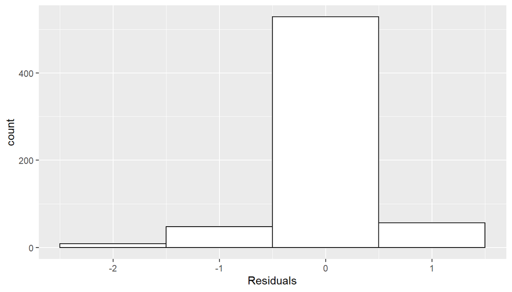

```r
ggplot(data = fit2, aes(x = .resid)) +
  geom_histogram(binwidth = 1, fill='white', color='black') +
  xlab("Residuals")
```

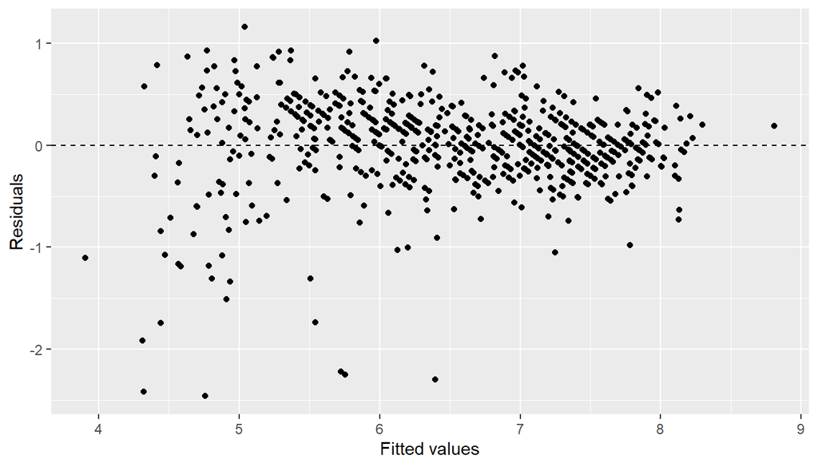

```r
ggplot(data = fit2, aes(x = .fitted, y = .resid)) +
  geom_point() +
  geom_hline(yintercept = 0, linetype = "dashed") +
  xlab("Fitted values") +
  ylab("Residuals")
```

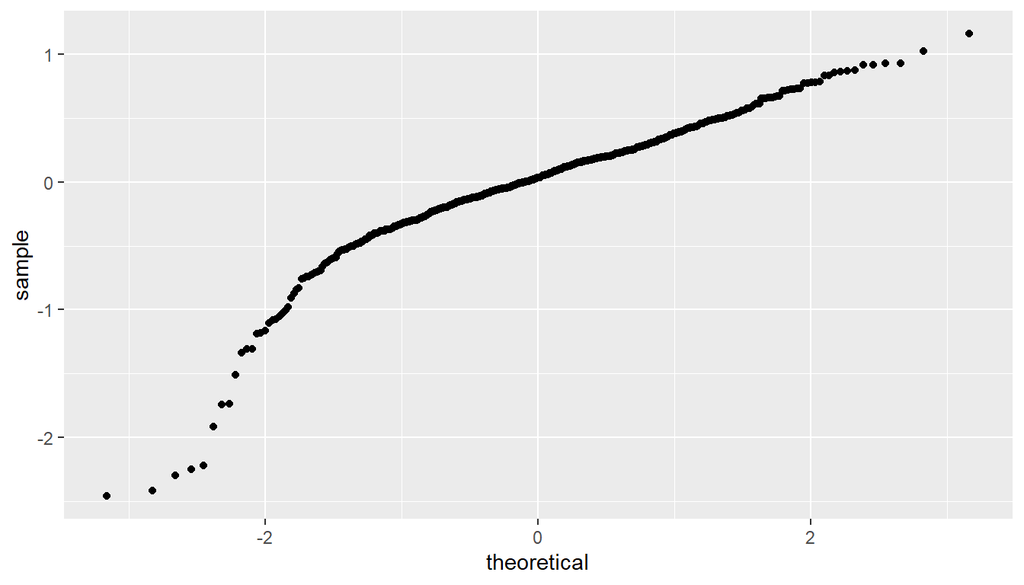

```r
ggplot(data = fit2, aes(sample = .resid)) +
  stat_qq()
```

## Part 5: Prediction

The movie chose was Deadpool(2016). Information extracted from imdb and rotten tomatoes websites respectively. Note: no.of votes are tabulated from us and non-us numbers of users.

```r
mov_pr<- data.frame(genre="Drama"
                    ,runtime=117
                    ,critics_score=85
                    ,audience_score=90
                    ,log_votes = log(405888))
pr <- predict(fit2, newdata=mov_pr, interval="confidence")
pr
```

```
##        fit      lwr      upr
## 1 7.916229 7.824102 8.008356
```

The prediction is 7.9 close to the actual 8. Our model is 95% confident that the rating for the movies lies between 7.82 and 8.00836.

## Part 6: Conclusion

Hence from the model we can predict the imdb rating using the 5 significant variables from a set of 17 variables. Paramount Pictures can make use of this data while planning future films.

There are potential shortcomings in these kinds of models, that is the predictive power is limited because the sample data is not representative. A larger number of observation that capture more variability in the population data in our data set is required to have a better measure of the models accuracy. Also there might be additional variables like if the movie has a sequel etc, would contribute to the accuracy of the model as well.

## Part 7: Referrences

https://stackoverflow.com

David M Diez, Christopher D Barr and Mine Cetinkaya-Rundel. “OpenIntro Statistics, Third Edition”. (2016).

“Statistics with R Specialization”, by Duke University on Coursera - (ongoing)

https://rpubs.com/Shobha_r/311126

https://www.imdb.com/title/tt1431045/

https://www.rottentomatoes.com/m/deadpool